# Prepare for CF Regression Analysis

Shunkei Kakimoto

# 1 Objectives

- remove data on landowners who own multiple farmlands across inside and outside of 5-miles or 10-miles buffers of LR side.
- For LR data, convert yearly well-level data to **yearly owner-level data**
  - Consider clustering variable: `cntyname`
  - Take weighted average ($sum(volaf*12)/sum(acres)$)
- Final output:
  - `reg_data_5mi`
  - `reg_data_10mi`

## 1.1 Data

```r
#/*--------------------------------*/
#' ## Data
#/*--------------------------------*/
# === NRD boundary === #
nrd_boud <-
 here("Shared/Data/WaterAnalysis/NRD_bd/BND_NaturalResourceDistricts_DNR.shp") %>%
 st_read() %>%
 filter(NRD_Name %in% c("Lower Republican", "Tri-Basin")) %>%
 st_transform(4269)
# === All well data === #
ir_data <-
  here("Shared/Data/WaterAnalysis/ir_data_nw.rds") %>%
  readRDS() %>%
  data.table() %>%
  .[source %in% c('Meter','METER','metered') & nrdname %in% c("Lower Republican", "Tri-Basin")] %>%
  .[,owner_name := paste0(firstname, "_", lastname)] %>%
  .[,nrd_owner_name := paste0(nrdname, " ", owner_name) ]

# === Regression Data (period: 2008-2015)  === #
w_analysis_dt <-
  here("Shared/Data/WaterAnalysis/w_analysis_dt.rds") %>%
  readRDS() %>%
  .[,nrd_owner_name := paste0(nrdname, " ", owner_name)] %>%
  .[year %in% 2008:2015 & usage <= 45]

# === Regression Data (period: 2008-2012) === #
reg_data <-
  w_analysis_dt %>%
  .[year %in% 2008:2012]
```

# 2 Identify landowners whose farmland located in both inside and outside of the 10-miles buffer

```r
# === A list of owners who owns farmland outside of the 5 and 10 mi buffer in LR side === #
ls_owners_out5mi_LR <-
  ir_data %>%
  .[nrdname=="Lower Republican" & in_5mi==0, nrd_owner_name] %>%
  unique()

ls_owners_out10mi_LR <-
  ir_data %>%
  .[nrdname=="Lower Republican" & in_10mi==0, nrd_owner_name] %>%
  unique()

# === Create "both_InOut_5mi" and "both_InOut_10mi" index === #
# Ex) both_InOut_5mi==1, if an landowner has farmland outside of the 5 miles in LR side
reg_data <-
  reg_data %>%
  .[, `:=`(
    both_InOut_5mi_LR = ifelse(nrd_owner_name %in% ls_owners_out5mi_LR, 1, 0),
    both_InOut_10mi_LR = ifelse(nrd_owner_name %in% ls_owners_out10mi_LR, 1, 0)
    )]
```

```r
# === 5 miles buffers === #
reg_data[in_5mi==1] %>%
  unique(., by="nrd_owner_name") %>%
  .[, .N, by=.(nrdname, both_InOut_5mi_LR) ] %>%
  .[order(nrdname)] %>%
  print()
```

```
            nrdname both_InOut_5mi_LR   N
1: Lower Republican                 0 304
2: Lower Republican                 1  82
3:        Tri-Basin                 0 444
```

```r
# === 10 miles buffers === #
reg_data[in_10mi==1] %>%
  unique(., by="nrd_owner_name") %>%
  .[, .N, by=.(nrdname, both_InOut_10mi_LR) ] %>%
  .[order(nrdname)] %>%
  print()
```

```
            nrdname both_InOut_10mi_LR   N
1: Lower Republican                  0 638
2: Lower Republican                  1  55
3:        Tri-Basin                  0 693
```

- 5 miles buffer criteria:
  - 82 owners in LR also have farmlands outside of the buffer
- 10 miles buffer criteria:
  - 55 owners in LR also have farmlands outside of the buffer

# 3 Create Raw Regression Data for 5 miles and 10 miles criterion, respectively

## 3.1 Regression data with 5 miles criterion

### 3.1.1 Problem

- **Which variable should be used for clustering?**
  - I used to use `tr` (combinations of “township” and “range” index) for clustering.
- However, since some farmers have multiple wells across `tr`, so `tr` cannot be used.
  - If a farmer has farmland across several “range”, the value of `tr` is not one, when we aggregated LR data by owner and year.
- We need some new geographic segmentation index which covers larger area.
  - Alternatives:
    - **County**
- Check weather all the farmlands owned by a single owner in LR located in the same county.
  - For those who have multiple wells across several counties, find in which county their large portion of farmlands were located based on the total acres by county.
  - Create `cntyname_fix`

### 3.1.2 Cluster variable: `cntyname` for `reg_data_LR_5mi` data

```r
# - Data on TB - #
reg_data_TB_5mi <-
  reg_data[in_5mi==1 & nrdname=="Tri-Basin",]

# - Data on LR - #
reg_data_LR_5mi <-
  reg_data[in_5mi==1 & both_InOut_5mi_LR==0 & nrdname=="Lower Republican",]

reg_data_5mi_raw <-
  bind_rows(reg_data_TB_5mi, reg_data_LR_5mi)
```

```r
# === A list of landowners whose farmlands are located in several counties  === #
ls_cnty_5mi <-
  reg_data_5mi_raw %>%
  distinct(nrd_owner_name, cntyname) %>%
  .[, index := rep(1, nrow(.)),] %>%
  dcast(.,nrd_owner_name ~ cntyname, value.var = "index") %>%
  replace(is.na(.), 0) %>%
  .[, total := rowSums(.SD), by = nrd_owner_name] %>%
  .[total>1, ]
```

Example maps for those farmlands are shown in the below.

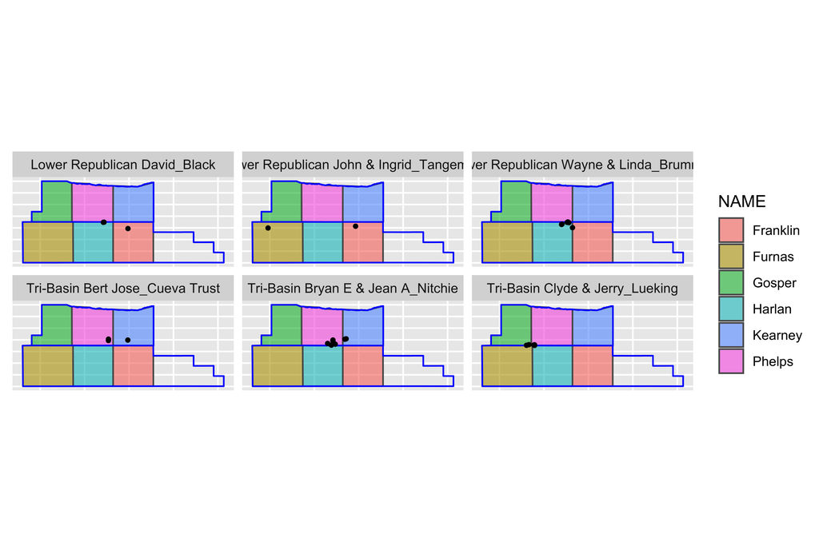

- Create `cntyname_fix` column which contains modified `cntyname`.
- In the below, I decided in which county the farmers should be belong to based on the total acres of the farmlands by county.

```r
which_cnty_5 <-
  reg_data_5mi_raw %>%
  .[nrd_owner_name %in% ls_cnty_5mi[, nrd_owner_name],] %>%
  distinct(nrd_owner_name, longdd, latdd, .keep_all = TRUE) %>%
  .[,.(sum_acres = sum(acres)), by = .(nrd_owner_name, cntyname)] %>%
  .[,.SD[sum_acres == max(sum_acres), ], by = nrd_owner_name]

which_cnty_5[, .N, by = cntyname]
```

```r
Phelps <- which_cnty_5[cntyname=="Phelps", nrd_owner_name]
Kearney <- which_cnty_5[cntyname=="Kearney", nrd_owner_name]
Gosper <- which_cnty_5[cntyname=="Gosper", nrd_owner_name]
Harlan <- which_cnty_5[cntyname=="Harlan", nrd_owner_name]
Furnas <- which_cnty_5[cntyname=="Furnas", nrd_owner_name]

reg_data_5mi_raw <-
  reg_data_5mi_raw %>%
  .[,cntyname_fix := case_when(
    nrd_owner_name %in% Phelps ~ "Phelps",
    nrd_owner_name %in% Kearney ~ "Kearney",
    nrd_owner_name %in% Gosper ~ "Gosper",
    nrd_owner_name %in% Harlan ~ "Harlan",
    nrd_owner_name %in% Furnas ~ "Furnas",
    TRUE ~ cntyname
  )]
```

```r
# === save the modified data  === #
saveRDS(reg_data_5mi_raw, here("Shared/Data/WaterAnalysis/reg_data_5mi_raw.rds"))
```

## 3.2 Regression data with 10 miles criterion

### 3.2.1 Cluster variable: `cntyname` for `reg_data_LR_10mi` data

```r
# - Data on TB - #
reg_data_TB_10mi <-
  reg_data[nrdname=="Tri-Basin",]

# - Data on LR - #
reg_data_LR_10mi <-
  reg_data[both_InOut_10mi_LR==0 & nrdname=="Lower Republican",]

reg_data_10mi_raw <-
  bind_rows(reg_data_TB_10mi, reg_data_LR_10mi)
```

```r
cnty_10 <-
  reg_data_10mi_raw %>%
  distinct(nrd_owner_name, cntyname) %>%
  .[, index := rep(1, nrow(.)),] %>%
  dcast(.,nrd_owner_name ~ cntyname, value.var = "index") %>%
  replace(is.na(.), 0) %>%
  .[, total := rowSums(.SD), by = nrd_owner_name]

# county_cl[total>1, nrd_owner_name]
cnty_10[total>1, ]
```

```r
# === Save the modified data === #
saveRDS(reg_data_10mi_raw, here("Shared/Data/WaterAnalysis/reg_data_10mi_raw.rds"))
```

```r
# === Check === #
cnty_10_check <-
  reg_data_10mi_raw %>%
  distinct(nrd_owner_name, cntyname_fix) %>%
  .[, index := rep(1, nrow(.)),] %>%
  dcast(.,nrd_owner_name ~ cntyname_fix, value.var = "index") %>%
  replace(is.na(.), 0) %>%
  .[, total := rowSums(.SD), by = nrd_owner_name]

# county_cl[total>1, nrd_owner_name]
cnty_10_check[total>1, ]
```